# dataVisualisation_analyses

```python
import matplotlib.pyplot as plt
import numpy as np
import pandas as pd

df = pd.read_csv('/Users/ruiz/Documents/Study/PNB3EE3/zongRuiyan/Zong_Ruiyan_Assignment/Data Visualization/assignment_dataVis_dataset.csv')
stats = df.groupby('condition').agg({'x':['mean', 'std'], 'y':['mean', 'std']})
stats
```

| condition | x mean | x std | y mean | y std |
| --- | --- | --- | --- | --- |
| condition_1 | 54.263273 | 16.765142 | 47.832253 | 26.935403 |
| condition_2 | 54.268730 | 16.769239 | 47.830823 | 26.935727 |
| condition_3 | 54.265882 | 16.768853 | 47.831496 | 26.938608 |
| condition_4 | 54.267341 | 16.768959 | 47.839545 | 26.930275 |

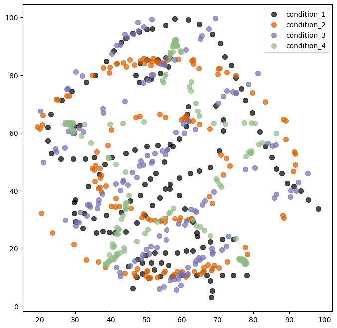

```python
# First visualize the whole dataset
y_values = df["y"].values
x_values = df["x"].values

conditions = df["condition"].values
unique_conditions = np.unique(conditions)

COLORS = ["black", "#D95F02", "#7570B3", "#91BA88"]

fig, ax = plt.subplots(figsize=(8,8))
for condition, color in zip(unique_conditions, COLORS):
    idxs = np.where(condition == conditions)
    # No legend will be generated if we don't pass label=species
    ax.scatter(
        x_values[idxs], y_values[idxs], label=condition,
        s=50, color=color, alpha=0.7
    )

ax.legend()
plt.show()
```

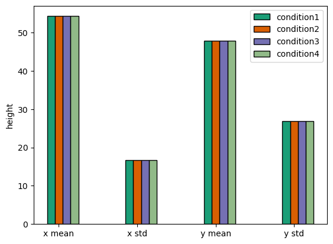

```
array([54.26327324, 16.76514204, 47.83225282, 26.93540349])
```

```python
# Then visualize the mean and std for each condition
# width of the bars
barWidth = 0.1

condition1 = stats.loc['condition_1'].values
condition2 = stats.loc['condition_2'].values
condition3 = stats.loc['condition_3'].values
condition4 = stats.loc['condition_4'].values

# The x position of bars
r1 = np.arange(len(condition1))
r2 = [x + barWidth for x in r1]
r3 = [x + barWidth for x in r2]
r4 = [x + barWidth for x in r3]

# Create blue bars
plt.bar(r1, condition1, width = barWidth, color = '#1B9E77', edgecolor = 'black', capsize=7, label='condition1')
plt.bar(r2, condition2, width = barWidth, color = '#D95F02', edgecolor = 'black', capsize=7, label='condition2')
plt.bar(r3, condition3, width = barWidth, color = '#7570B3', edgecolor = 'black', capsize=7, label='condition3')
plt.bar(r4, condition4, width = barWidth, color = '#91BA88', edgecolor = 'black', capsize=7, label='condition4')


# general layout
plt.xticks([r + barWidth for r in range(len(condition1))], ['x mean', 'x std', 'y mean', 'y std'])
plt.ylabel('height')
plt.legend()

# Show graphic
plt.show()
condition1
```

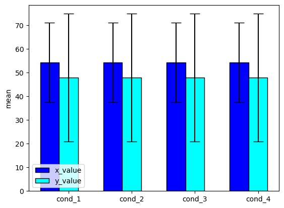

```python
barWidth = 0.3

# Choose the height of the x_value bars
bars1 = stats['x','mean']

# Choose the height of the y_value bars
bars2 = stats['y','mean']

# Choose the height of the error bars (bars1)
yer1 = stats['x','std']

# Choose the height of the error bars (bars2)
yer2 = stats['y','std']

# The x position of bars
r1 = np.arange(len(bars1))
r2 = [x + barWidth for x in r1]

# Create blue bars
plt.bar(r1, bars1, width = barWidth, color = 'blue', edgecolor = 'black', yerr=yer1, capsize=7, label='x_value')

# Create cyan bars
plt.bar(r2, bars2, width = barWidth, color = 'cyan', edgecolor = 'black', yerr=yer2, capsize=7, label='y_value')

# general layout
plt.xticks([r + barWidth for r in range(len(bars1))], ['cond_1', 'cond_2', 'cond_3', 'cond_4'])
plt.ylabel('mean')
plt.legend()

# Show graphic
plt.show()
```

# What can be concluded from the dataset?

# What did you find most challenging about this assignment?

In the second plot, the orginal code utilized the column values to draw the graph (like I did with the third plot), so when I was trying to use the row values instead (so I can have the values for each conditions side by side, which will result in better visualization and easier comparison).

# What did you learn in completing this assignment? What are you still curious about?

I learn how to complete basic data visualization by utilizing the existing code template and create useful plots efficiently. I'm still curious about how to change the font type (for example, times new roman).

# Why is it important to visualize data?

People are usually not as sentive to the numerical data as the visual color and patterns. Visualizing the data helps people obtain more information, such as the trends, correlations and interactions between different conditions. It also makes the scientific communication easier because researchers doesn't have to show all the numerical data to explain their result, instead, a plot will be straightforward and easy to understand.